# Data Fabric of My Life

M. Samuel - January 19th 2019

* Mostly suppressing all code, but keeping just a bit for nerds like Nava, Steve, and you (?), to keep me honest

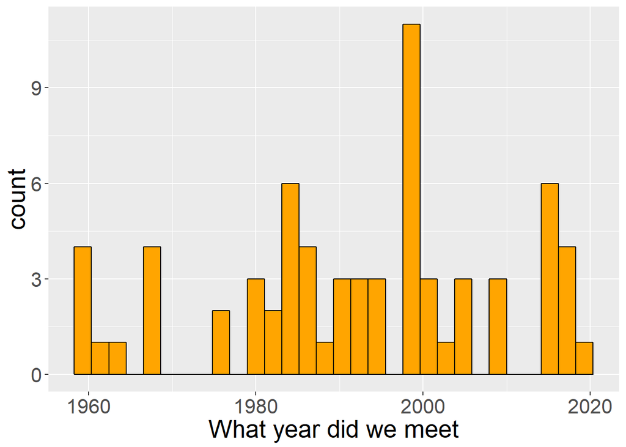

```r
pDat              <- read.csv("PartyData.csv",as.is=TRUE)
pDat[is.na(pDat)] <- 0
pDat              <- filter(pDat,Who != "Michael")

myPie <- function(dat,lab,myCol=c("cyan","red"),myAngle=110) {
         pie(table(dat),label=lab,
         init.angle=myAngle,
         col = myCol,
         cex=1.5)
}
```

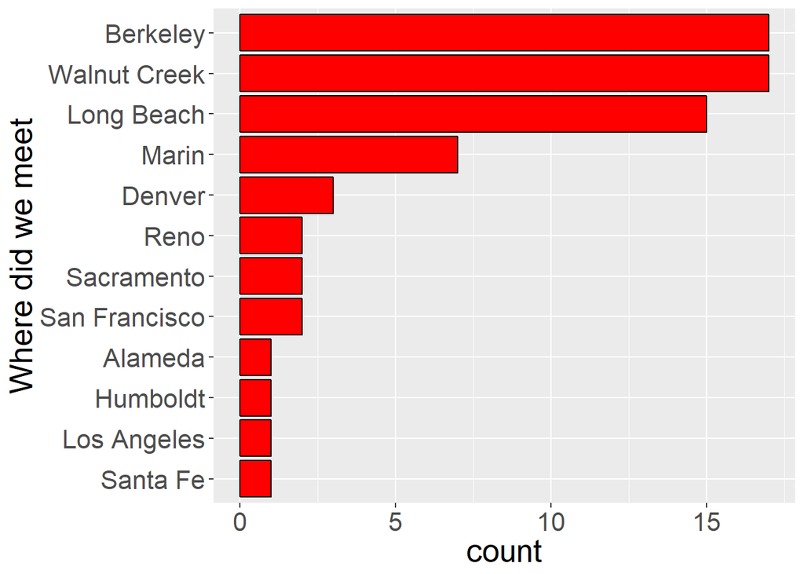

```r
ggplot(pDat, aes(x= forcats::fct_rev(forcats::fct_infreq(Where) ))) +
     geom_bar(fill="red",color="black") +
     coord_flip()+
     theme(text = element_text(size = myTextSize)) +
     labs(x = "Where did we meet")
```

## Proportion of each single relationship dimension

- several dimensions have complex definitions, contact author for further discussion

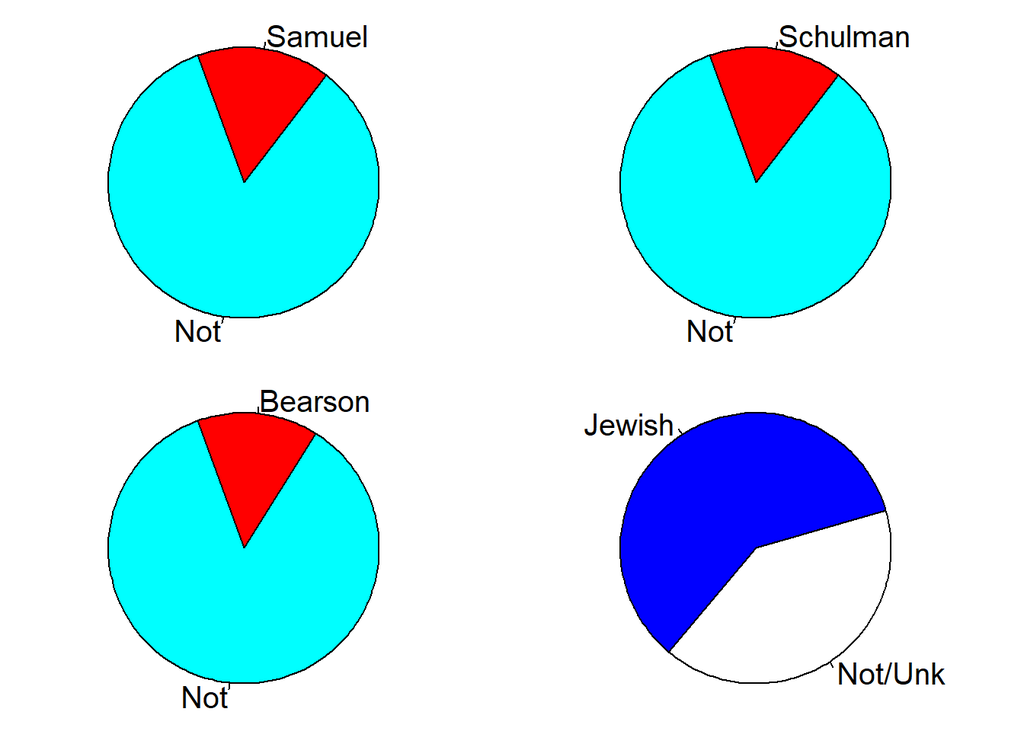

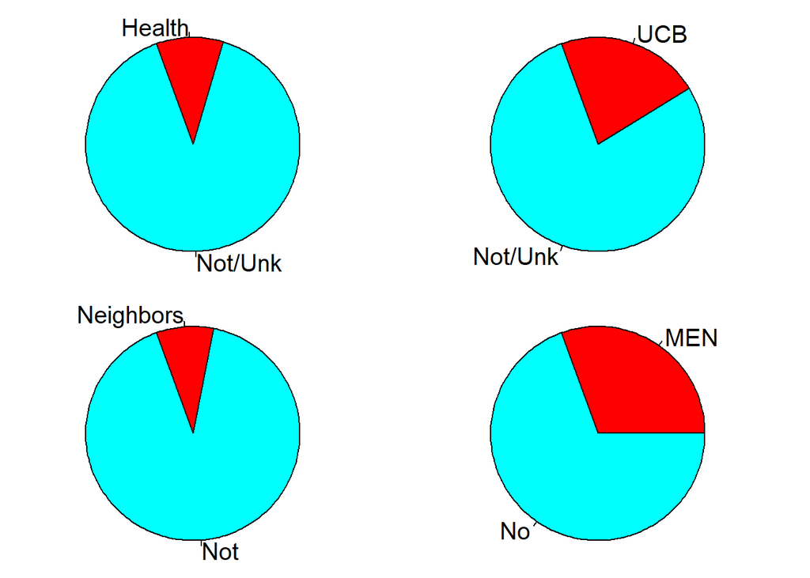

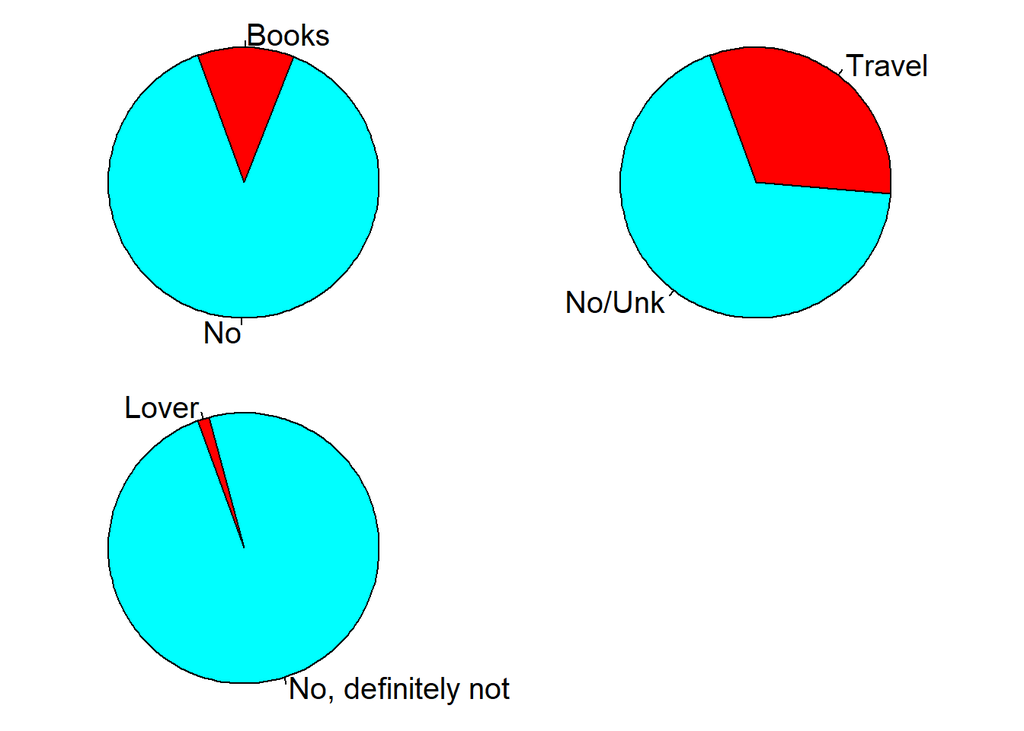

### Connection Dimentioality Score = sum of individual scores

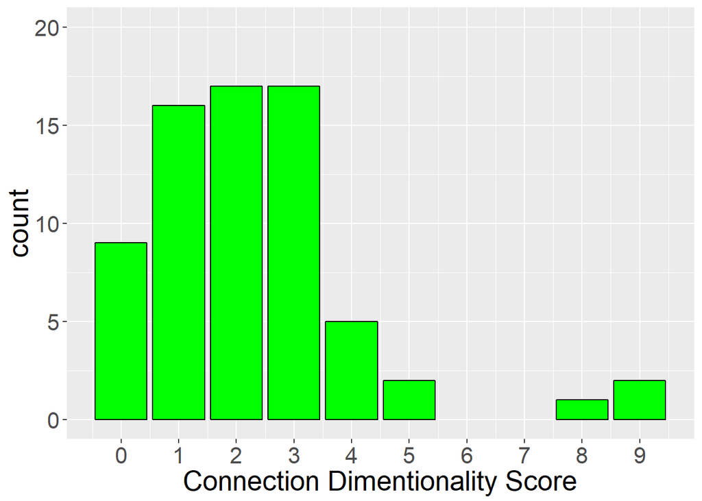

#### why are there several ‘0’s’ on dimentionality score

#### review of raw data indicated a missing dimension, “B Connection” = persons who I know, originally, primarily by a connection to a Bearson

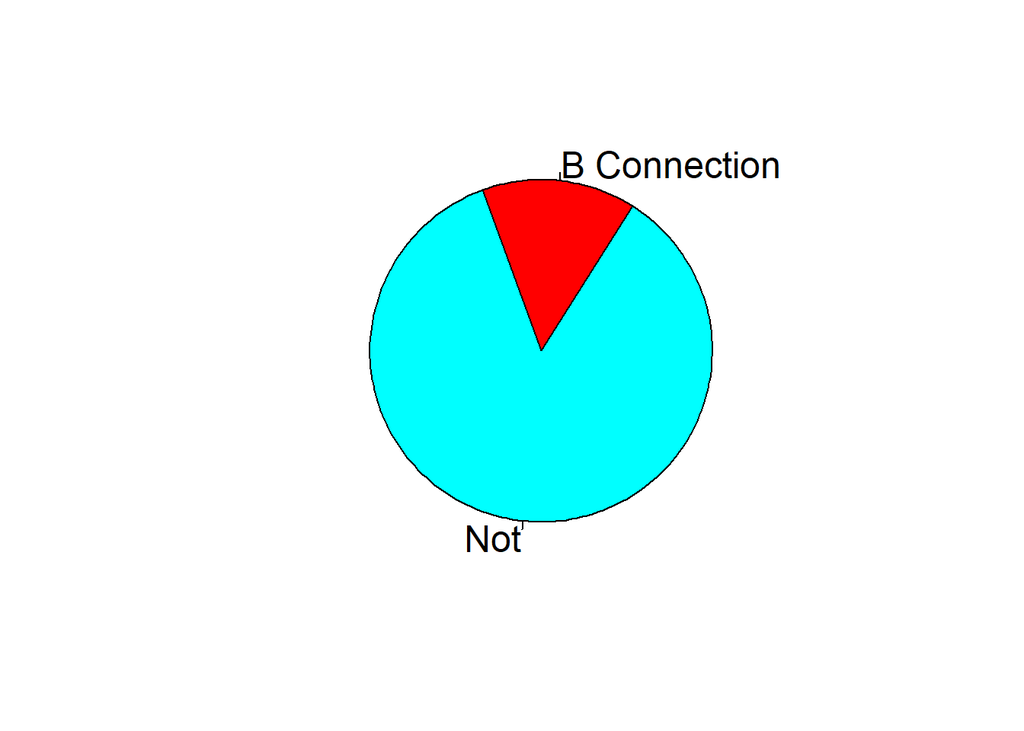

```r
myPie(BearsonDegree, c("Not","B Connection"))
```

#### Corrected data. Still a few “0’s”, but hardly 0’s to me–mostly partners of people I have met more recently…

#### And who has Score = 8? Jane!

#### And who has Score = 9? Leah and Louis! (score higher than Jane because of their Schulman and Bearson blood)

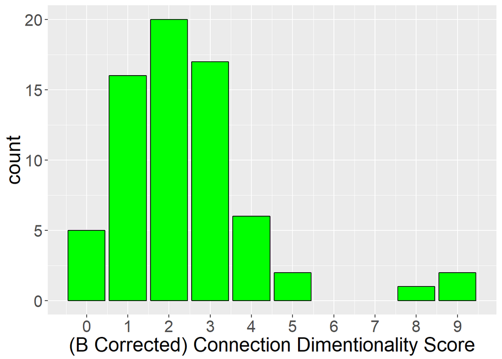

### Time to take a puff, and examine a violin plot with jittered data, exploring the relationship of when we met to where we met

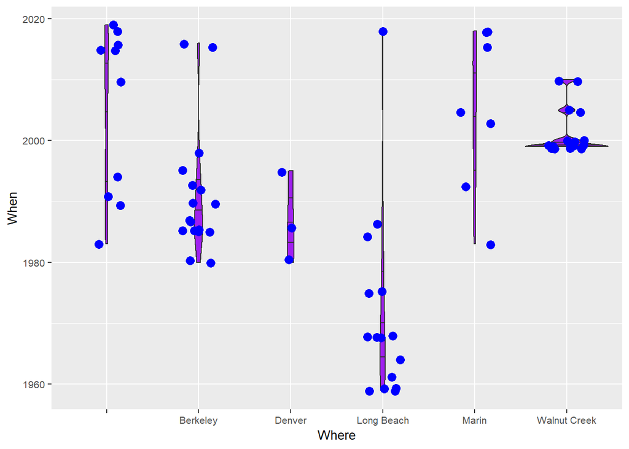

## Putting it all together; yes LOTS of amazing stuff! But is that really it, my whole life?

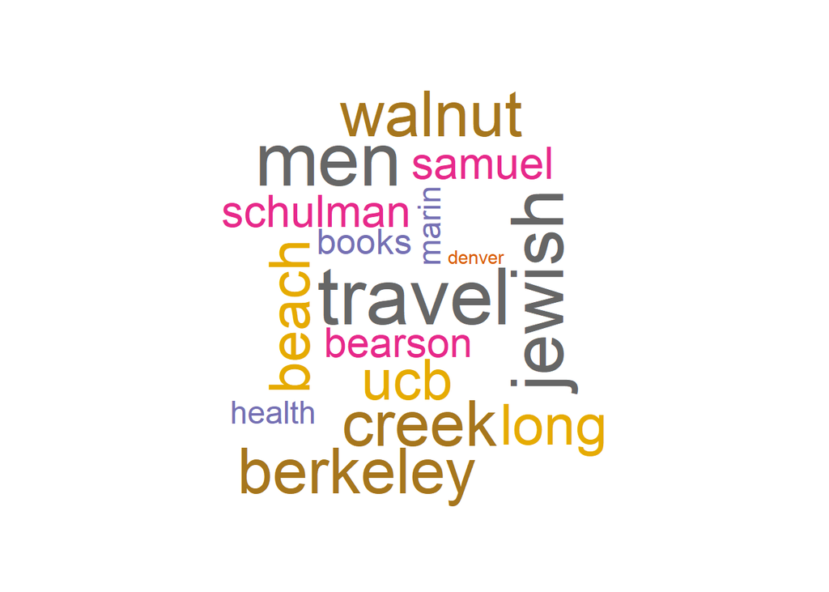

## Hardley…LOTS more details, sweetness, and love, based on a few words I wrote about every single one of you, and then put together this way:

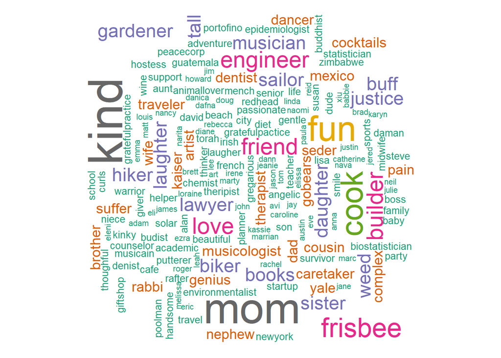

## And, FINALLY, to wrap it up, thank you all!

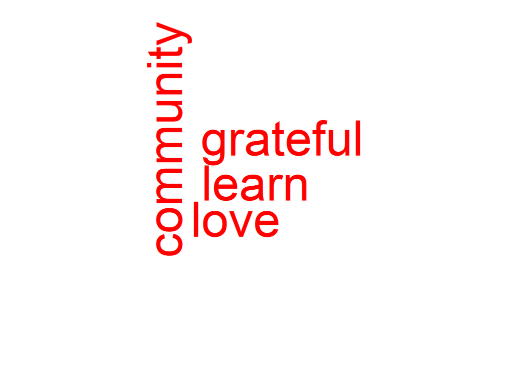

```
## [1] TRUE
```

```
## [1] TRUE
```